# **GRASS GIS for remote sensing data processing and analysis**

## 8. Spectral indices of vegetation and water

We will use i.vi and i.wi (addon) to estimate NDVI and NDWI vegetation and water indices. See [i.vi](https://grass.osgeo.org/grass-stable/manuals/i.vi.html) and [i.wi](https://grass.osgeo.org/grass-stable/manuals/addons/i.wi.html) for more other available indices.

```python
# estimate vegetation indices
gs.run_command("i.vi",
               red="T17SQV_20220528T155819_B04_10m",
               nir="T17SQV_20220528T155819_B08_10m",
               output="T17SQV_20220528T155819_NDVI_10m",
               viname="ndvi")

# add semantic label
gs.run_command("r.support",
               map="T17SQV_20220528T155819_NDVI_10m",
               semantic_label="S2_NDVI")
```

```python
# install extension
gs.run_command("g.extension", extension="i.wi")
```

```python
# estimate water indices
gs.run_command("i.wi",
               green="T17SQV_20220528T155819_B03_10m",
               nir="T17SQV_20220528T155819_B08_10m",
               output="T17SQV_20220528T155819_NDWI_10m",
               winame="ndwi_mf")

# set ndwi color palette
gs.run_command("r.colors", map="T17SQV_20220528T155819_NDWI_10m", color="ndwi")

# add semantic label
gs.run_command("r.support",
               map="T17SQV_20220528T155819_NDWI_10m",
               semantic_label="S2_NDWI")
```

```python
# check metadata of NDVI
gs.raster_info(map="T17SQV_20220528T155819_NDVI_10m")
```

```python
# interactive maps
idx_map = gj.InteractiveMap(width = 400, use_region=True, tiles="OpenStreetMap")
idx_map.add_raster("T17SQV_20220528T155819_NDVI_10m", opacity=0.7)
idx_map.add_raster("T17SQV_20220528T155819_NDWI_10m", opacity=0.7)
idx_map.add_layer_control(position = "bottomright")
idx_map.show()
# ... use the layer selector in the corner to enable/disable the NDVI/NDWI layers
```

#### GRASS GIS maps as numpy arrays

GRASS maps can be read as numpy arrays thanks to the array function of the grass.script library. This facilitates many operations with python libraries that require an array as input. In this case, we demonstrate its use plotting an histogram.

```python
# Import required libraries
import numpy as np
import seaborn as sns
import matplotlib.pyplot as plt
from grass.script import array as garray

# Read NDVI as numpy array
ndvi = garray.array(mapname="T17SQV_20220528T155819_NDVI_10m", null="nan")
ndwi = garray.array(mapname="T17SQV_20220528T155819_NDWI_10m", null="nan")
print(ndvi.shape,ndwi.shape)
```

```python
# Plot NDVI and NDWI
sns.set_style('darkgrid')
fig, axs = plt.subplots(1, 2, figsize=(7, 7))
sns.histplot(ax=axs[0], data=ndvi.ravel(), kde=True, color="olive")
sns.histplot(ax=axs[1], data=ndwi.ravel(), kde=True, color="skyblue")
plt.show()
```

## 10. NDVI time series data processing

### A few concepts of time series data processing in GRASS GIS

GRASS GIS offers specialized tools for spatio-temporal data processing, see GRASS documentation [temporalintro](https://grass.osgeo.org/grass-stable/manuals/temporalintro.html) for details and the [temporal data processing](https://grasswiki.osgeo.org/wiki/Temporal_data_processing) wiki for examples and a workflow tutorial.

GRASS introduces three special data types that are designed to handle time-series:

- *Space-time raster datasets* (`strds`) for managing raster map time series.
- *Space-time 3D raster datasets* (`str3ds`) for managing 3D raster map time series.
- *Space-time vector datasets* (`stvds`) for managing vector map time series.

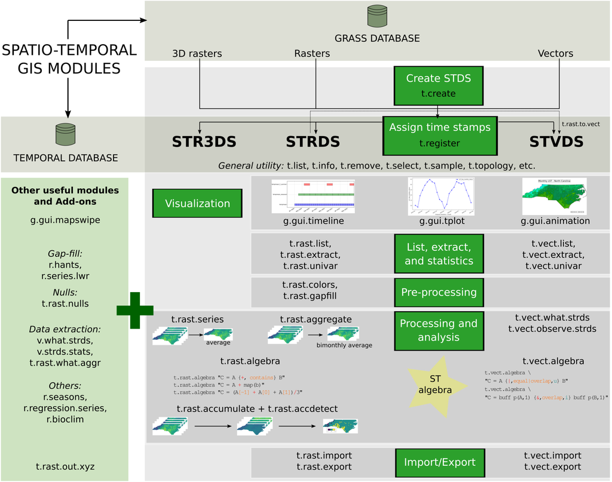

### Create space-time dataset

At this moment a new space-time dataset can be created by means of [t.create](https://grass.osgeo.org/grass-stable/manuals/t.create.html) and all imported Sentinel bands registered with [t.register](https://grass.osgeo.org/grass-stable/manuals/t.register.html) and the timestamps file we created when we imported S2 bands.

```python
gs.run_command("t.create",
               output="s2_nc",
               title="Sentinel L2A - North Carolina",
               desc="Tile T17SQV - 2022")

gs.run_command("t.register",
               input="s2_nc",
               file=s2_timestamps)
```

Let’s check basic metadata with [t.info](https://grass.osgeo.org/grass-stable/manuals/t.info.html) and list the registered maps with [t.rast.list](https://grass.osgeo.org/grass-stable/manuals/t.rast.list.html).

```python
# Print time series info
print(gs.read_command("t.info", input="s2_nc"))
```

```python
# List registered bands in the space-time cube
print(gs.read_command("t.rast.list",
                      input="s2_nc",
                      columns="name,start_time,semantic_label"))
```

We’ll now use a special syntaxis to list only band 4 raster maps withing the time series:

```python
# List only band 4 maps
print(gs.read_command("t.rast.list",
                      input="s2_nc.S2_4",
                      columns="name,start_time,semantic_label"))
```

### NDVI Space-Time computation

For NDVI computation the 4th and 8th bands are required, as we saw above for a single map. Now, we will create a time series of NDVI maps. We will take advantage of the semantic labels syntax and use [t.rast.mapcalc](https://grass.osgeo.org/grass-stable/manuals/t.rast.mapcalc.html) to estimate NDVI for all the timestamps in the time series, using band 4 and 8 subsets.

```python
gs.run_command("t.rast.mapcalc",
               inputs="s2_nc.S2_8,s2_nc.S2_4",
               output="s2_ndvi",
               basename="s2_ndvi",
               expression="float(s2_nc.S2_8 - s2_nc.S2_4) / (s2_nc.S2_8 + s2_nc.S2_4)")
```

When computation is finished, the *ndvi* color table can be set with [t.rast.colors](https://grass.osgeo.org/grass-stable/manuals/t.rast.colors.html):

```python
gs.run_command("t.rast.colors", input="s2_ndvi", color="ndvi")
```

```python
print(gs.read_command("t.info", input="s2_ndvi"))
```

### Time series plots

Let’s check content of the new dataset by means of [t.rast.list](https://grass.osgeo.org/grass-stable/manuals/t.rast.list.html):

```python
print(gs.read_command("t.rast.list",
                      input="s2_ndvi",
                      columns="name,start_time,min,max"))
```

If we save the previous output to a file, we can then plot the min and max time series:

```python
gs.run_command("t.rast.list",
                input="s2_ndvi",
                columns="name,start_time,min,max",
                format="csv",
                separator="comma",
                output=os.path.join(homedir,"ndvi.csv"))
```

```python
# Read the csv and plot
ndvi = pd.read_csv(os.path.join(homedir,"ndvi.csv"))
ndvi.plot(0, [2,3], subplots=False)
```

We could also use [t.rast.univar](https://grass.osgeo.org/grass-stable/manuals/t.rast.univar.html) to obtain extended statistics:

```python
# Get extended univar stats and save them as a csv file
gs.run_command("t.rast.univar",
                flags="e",
                input="s2_ndvi",
                output=os.path.join(homedir,"ndvi_ext_stats.csv"),
                separator="comma")
```

```python
# Read the csv and plot
ndvi = pd.read_csv(os.path.join(homedir,"ndvi_ext_stats.csv"))
ndvi['start'] = pd.to_datetime(ndvi.start, format="%Y-%m-%d", exact=False)
ndvi.plot.line(1, [3,4,5], subplots=False)
```

### Query time series in a single point

`g.region` command allows us to get the coordinates of the center of the computational region, we’ll use those to query the NDVI time series.

```python
# Get region center coordinates for query (center_easting, center_northing values)
gs.region(complete=True)
```

```python
# Query map at center coordinates
print(gs.read_command("t.rast.what",
                      strds="s2_ndvi",
                      coordinates="637500,221750",
                      layout="col",
                      flags="n"))
```

### Time series animation

Note: [TimeSeriesMap()](https://grass.osgeo.org/grass-stable/manuals/libpython/grass.jupyter.html?highlight=timeseriesmap#module-grass.jupyter.timeseriesmap) of `grass.jupyter` is still experimental and under development.

```python
### YET TO BE SKIPPED - in GRASS GIS 8.2.0 it takes "forever", bugfix pending.

## reduce resolution for faster display of time series, save original first for later
#gs.parse_command("g.region", save="default_res")
#gs.parse_command("g.region", flags="pa", res=50)

## Display newly created NDVI time series map
#ndviseries = gj.TimeSeriesMap(use_region=True)
#ndviseries.add_raster_series("s2_ndvi", fill_gaps=False)
#ndviseries.d_legend(color="black", at=(10,40,2,6))
#ndviseries.d_barscale()
#ndviseries.show()  # Create TimeSlider

# optionally, write out to animated GIF
# ndviseries.save("image.gif")
```

```python
## restore original region
#gs.parse_command("g.region", region="default_res")
```

## 11. Creating an image stack (imagery group)

**Stack of maps = imagery group**

When you work with a stack of raster maps (e.g., R-G-B channels or more) in GRASS GIS, you can best handle this stack by creating a raster group with [i.group](https://grass.osgeo.org/grass-stable/manuals/i.group.html). It is just based on metadata, so it does not take up more disk space.

```python
# Since imagery groups can not be overwritten,
# we delete a potentially leftover "s2" group from a previous run
gs.run_command("g.remove",
               type="group",
               name="s2",
               flags="f")
```

```python
# Generate list of selected S2 maps
s2_maps = gs.list_grouped(type="raster", pattern="*20220528T155819*")['sentinel2']
print(s2_maps)
```

```python
# Create group and subgroup with S2 bands
gs.run_command("i.group", group="s2", subgroup="s2", input=s2_maps)
print(gs.read_command("i.group", group="s2", flags="l"))
```

## 12. Object recognition with image segmentation

We’ll use [i.segment](https://grass.osgeo.org/grass-stable/manuals/i.segment.html) to perform image segmentation. The resulting map will be used together with S2 bands, NDVI and NDWI to perform supervised classification.

```python
# Threshold = 0 merges only identical segments; threshold = 1 merges all
gs.run_command("i.segment",
               group="s2",
               threshold="0.05",
               minsize="100",
               output="sentinel_segments_min100",
               goodness="sentinel_segments_goodness_min100",
               memory=2000)
```

```python
# Display newly created segments raster map
segments = gj.InteractiveMap(width = 400, use_region=True)
segments.add_raster("sentinel_segments_min100", opacity=0.3)
segments.add_raster("s2_ndvi_4", opacity=0.3)
segments.add_layer_control(position = "bottomright")
segments.show()
```

```python
# Show univariate statistics of goodness-of-fit raster map, with extended statistics (quartiles)
print(gs.read_command("r.univar",
                      map="sentinel_segments_goodness_min100",
                      flags="ge"))
```

```python
# Assign color table (low fit values: blue; high fit values: green)
gs.run_command("r.colors",
               map="sentinel_segments_goodness_min100",
               color="byg",
               flags="e")
```

```python
# Display newly created goodness-of-fit raster map
segments = gj.InteractiveMap(width = 400, use_region=True)
segments.add_raster("sentinel_segments_goodness_min100", opacity=0.8)
segments.add_vector("urban_area_raleigh")
segments.add_layer_control(position = "bottomright")
segments.show()
```

## 13. Supervised Classification: RandomForest

We will now demonstrate a very much simplified workflow to perform a supervised [Random Forest classification](https://en.wikipedia.org/wiki/Random_forest).

We will feed the following data into the model:

- NDVI and NDWI maps (created above)
- image segmentation (created above)
- random training points extracted from landuse map

First we inspect the raster maps available in the current mapset (i.e., `sentinel2`), just to recall their names.

```python
gs.list_grouped(type="raster")["sentinel2"]
```

### Creation of a classification training map by sampling from existing data

In order to generate training data for the Sentinel-2 image classification, we will use the [National Land Cover Database (NLCD) 2019](https://www.lib.ncsu.edu/gis/lulc). It is available for download (30m raster map) from [here](https://drive.google.com/open?id=18D99kuotQp_BkxBnkn8OS3qgCeLVwovb&authuser=0). However, we have already prepared the dataset (the `nc_nlcd2019` landuse map). We will use it to perform stratified sampling to retrieve training data.

```python
# Check raster categories of landuse map
print(gs.read_command("r.category",
                      map="nc_nlcd2019",
                      separator="comma"))
```

```python
# display nc_nlcd2019 landuse raster map
lulc = gj.InteractiveMap(width = 400, use_region=True, tiles="OpenStreetMap")
lulc.add_raster("nc_nlcd2019", opacity=0.6)
lulc.add_layer_control(position = "bottomright")
lulc.show()
```

We already note differences between the underlying OpenStreetMap data and the 30m NLCD map.

```python
# show simple legend
legend = gj.Map(width=400, use_region=True)
# at=bottom,top,left,right, percentage of screen coordinates (0,0 is lower left)
legend.d_legend(raster="nc_nlcd2019",
                title="Classes",
                fontsize=10, at=(10, 90, 50, 90),
                flags="n")
legend.show()
```

### Random sampling from rasterized simplified landuse map

We now perform stratified sampling, i.e. we extract for each land use class `n` sampling points, using the GRASS GIS addon [r.sample.category](https://grass.osgeo.org/grass-stable/manuals/addons/r.sample.category.html).

First, we install this addon.

```python
gs.run_command("g.extension", extension="r.sample.category")
```

```python
# Stratified random sampling, generated vector points
gs.run_command("r.sample.category",
               input="nc_nlcd2019",
               output="landuse_train",
               n="100")
```

```python
# display newly created vector points map
train = gj.InteractiveMap(width = 400, use_region=True)
train.add_raster("nc_nlcd2019", opacity=0.7)
train.add_vector("landuse_train")
train.add_layer_control(position = "bottomright")
train.show()
```

```python
# List column names of vector points map
gs.vector_columns("landuse_train",
                  getDict=False)
```

```python
# Show vector attribute table
gs.vector_db_select("landuse_train")
```

```python
# Check column data types
print(gs.read_command("v.info", map="landuse_train", flags="c"))
```

Since the machine learning classifier expects raster points as input, we convert the vector sampling points accordingly using [v.to.rast](https://grass.osgeo.org/grass-stable/manuals/v.to.rast.html).

```python
# Convert points from vector to raster model
gs.run_command("v.to.rast",
               input="landuse_train",
               output="landuse_train",
               use="attr",
               attribute_column="nc_nlcd2019",
               label_column="label")
```

```python
# Check raster categories of new raster training map
# Skip reporting on empty cells
print(gs.read_command("r.report",
                      map="landuse_train",
                      flags="n"))
```

```python
# Display newly created raster map - zoom in to better spot the raster sampling points
train = gj.InteractiveMap(width = 400, use_region=True)
train.add_raster("landuse_train", opacity=0.8)
train.add_layer_control(position = "bottomright")
train.show()
```

### Perform machine learning model training (RandomForest)

First we have to install the [r.learn.ml2](https://grass.osgeo.org/grass-stable/manuals/addons/r.learn.ml2.html) extention. It consists of two modules: `r.learn.train` and `r.learn.predict`.

```python
# Install ML extension
gs.run_command("g.extension", extension="r.learn.ml2")
```

```python
# Add segmentation map created above to group and subgroup already populated with S2 bands, NDWI and NDVI
gs.run_command("i.group",
               group="s2",
               subgroup="s2",
               input="sentinel_segments_min100")

# List group content
print(gs.read_command("i.group", group="s2", flags="l"))
```

We now train the ML model using [r.learn.train](https://grass.osgeo.org/grass-stable/manuals/addons/r.learn.train.html), with model “RandomForestClassifier”.

```python
# Train a random forest classification model using r.learn.train
gs.run_command("r.learn.train",
               group="s2",
               training_map="landuse_train",
               model_name="RandomForestClassifier",
               n_estimators="500",
               save_model=os.path.join(homedir, "rf_model.gz"))
```

The model has been stored in the file `rf_model.gz` for use in the prediction step of the supervised classification.

```python
os.listdir(homedir)
```

### Perform ML supervised classification

The trained model will now be applied to the entire dataset.

```python
# Perform prediction using r.learn.predict
gs.run_command("r.learn.predict",
               group="s2",
               load_model=os.path.join(homedir, "rf_model.gz"),
               output="sentinel_rf")
```

```python
# Set color table, we transfer the colors from the original landuse map
gs.run_command("r.colors", map="sentinel_rf", raster="nc_nlcd2019")
```

With this, the (oversimplified) supervised classification has been completed and we can display the result.

### Reporting and display

```python
# Display newly created sentinel_rf map
rfmap = gj.InteractiveMap(width = 600, tiles="OpenStreetMap")
rfmap.add_raster("sentinel_rf", opacity=0.7)
# rfmap.add_raster("nc_nlcd2019", opacity=0.7)
rfmap.add_layer_control(position = "bottomright")
rfmap.show()
```

```python
# Show legend
legend = gj.Map(width=400, use_region=True)
legend.d_legend(raster="sentinel_rf",
                title="Classes",
                fontsize=14,
                at=(10, 80, 10, 40),
                flags="n")
legend.show()
```

```python
# Show class distribution in percent
print(gs.read_command("r.report",
                      map="sentinel_rf",
                      units="p",
                      flags="h"))
```

```python
# export map to COG
gs.run_command("r.out.gdal",
               flags="fmt", #
               input="sentinel_rf",
               output=os.path.join(homedir, "nc_sentinel2_RF.tif"),
               format="COG",
               overviews="4")
```

Keep in mind, this classification was just a simplified example to show how the procedure works.

At this moment you should use [r.kappa](https://grass.osgeo.org/grass-stable/manuals/r.kappa.html) to calculate accuracy of classification. As this step would require either field observation data or manual interpretation of the scene, we’ll leave this as an exercise to do at home.

```python
# Open the tif in QGIS, adapt path accordingly
!qgis $homedir/nc_sentinel2_RF.tif
```

## 14. Supervised Classification: Maximum Likelihood

Let’s first check the semantic labels of the bands in our `s2` group:

```python
band_list = gs.read_command("i.group", group="s2", flags="lg")
```

```python
# Add semantic label to the segmentation
gs.run_command("r.support",
               map="sentinel_segments_min100",
               semantic_label="S2_seg")
```

```python
for m in band_list.split():
    sl = gs.raster_info(m)['semantic_label']
    print(m,sl)
```

Now, we generate the signature file based on the training sample that we obtained earlier, this will then be the input for the maximum likelihood classification

```python
# obtain signature files
gs.run_command("i.gensig",
               trainingmap="landuse_train",
               group="s2",
               subgroup="s2",
               signaturefile="sig_sentinel")
```

```python
# perform ML supervised classification
gs.run_command("i.maxlik",
               group="s2",
               subgroup="s2",
               signaturefile="sig_sentinel",
               output="sentinel_maxlik")
```

```python
# check classes
print(gs.read_command("r.category",
                      map="sentinel_maxlik",
                      separator="comma"))
```

In GRASS 8.2+, [i.maxlik](https://grass.osgeo.org/grass-stable/manuals/i.maxlik.html) classifier does not preserve the original class values in the output. Thus, here is a lookup-table for original class numbers and new category values:

| class | nlcd_class | landuse | RGB |
| --- | --- | --- | --- |
| 1 | 11 | Open Water | 072:109:162 |
| 2 | 21 | Developed, Open Space | 225:205:206 |
| 3 | 22 | Developed, Low Intensity | 220:152:129 |
| 4 | 23 | Developed, Medium Intensity | 241:001:000 |
| 5 | 24 | Developed, High Intensity | 171:001:001 |
| 6 | 41 | Deciduous Forest | 108:169:102 |
| 7 | 42 | Evergreen Forest | 029:101:051 |
| 8 | 43 | Mixed Forest | 189:204:147 |
| 9 | 81 | Hay/Pasture | 221:216:062 |
| 10 | 90 | Woody Wetlands | 187:215:237 |

```python
# Set color table
colours = ["1 072:109:162", "2 225:205:206", "3 220:152:129", "4 241:001:000", "5 171:001:001", "6 108:169:102", "7 029:101:051", "8 189:204:147", "9 221:216:062", "10 187:215:237"]
gs.write_command("r.colors", map="sentinel_maxlik", rules="-", stdin="\n".join(colours))
```

```python
# display results
maxlik_sup_class = gj.Map(width=500, use_region=True)
maxlik_sup_class.d_rast(map="sentinel_maxlik")
maxlik_sup_class.d_legend(raster="sentinel_maxlik",
                          title="Class",
                          fontsize=12,
                          at=(70, 95, 75, 90),
                          flags="bn")
maxlik_sup_class.d_barscale()
maxlik_sup_class.show()
```

```python
# percentage of each class
print(gs.read_command("r.report",
                      map="sentinel_maxlik",
                      units="p",
                      flags="h"))
```

```python
# class statistics: NDVI
class_stats = gs.read_command("r.univar",
                              map="T17SQV_20220528T155819_NDVI_10m",
                              zones="sentinel_maxlik",
                              flags="t")
```

```python
pd.read_csv(StringIO(class_stats),
            delimiter="|",
            usecols=[1, 4, 5, 7])
```

Next, and to demonstrate the use of semantic labels, we will classify another sentinel scene with the same signature obtained earlier. To this aim, we need to: 1. create a new imagery group for a different scene with the exact same band order 1. estimate NDVI and NDWI and assign semantic labels 1. run a segmentation and assign semantic labels 1. check group and semantic labels 1. run `i.maxlik`

Be ware – changes over time (phenology, weather) will make spectral signatures to not fit well or at all. Do not use same signatures for a different season!

```python
s2_maps = gs.list_grouped(type="raster", pattern="*20220617*")['sentinel2']
s2_maps
```

```python
# Since imagery groups can not be overwritten,
# we delete any leftover "s2_new" group from previous runs
gs.run_command("g.remove",
               type="group",
               name="s2_new",
               flags="f")
```

```python
gs.run_command("i.group", group="s2_new", subgroup="s2_new", input=s2_maps)
print(gs.read_command("i.group", group="s2_new", flags="l"))
```

```python
# estimate NDVI
gs.run_command("i.vi",
               red="T17SQV_20220617T155829_B04_10m",
               nir="T17SQV_20220617T155829_B08_10m",
               output="T17SQV_20220617T155829_NDVI_10m",
               viname="ndvi")

# add semantic label
gs.run_command("r.support",
               map="T17SQV_20220617T155829_NDVI_10m",
               semantic_label="S2_NDVI")
```

```python
# estimate NDWI
gs.run_command("i.wi",
               green="T17SQV_20220617T155829_B03_10m",
               nir="T17SQV_20220617T155829_B08_10m",
               output="T17SQV_20220617T155829_NDWI_10m",
               winame="ndwi_mf")

# add semantic label
gs.run_command("r.support",
               map="T17SQV_20220617T155829_NDWI_10m",
               semantic_label="S2_NDWI")
```

```python
# add NDVI and NDWI to s2_mew group
gs.run_command("i.group",
               group="s2_new",
               subgroup="s2_new",
               input="T17SQV_20220617T155829_NDVI_10m,T17SQV_20220617T155829_NDWI_10m")

# print maps in the group
print(gs.read_command("i.group", group="s2_new", flags="l"))
```

```python
# Run segmentation
gs.run_command("i.segment",
               group="s2_new",
               threshold="0.05",
               minsize="100",
               output="sentinel_new_segments_min100",
               goodness="sentinel_new_segments_goodness_min100")
```

```python
# Add semantic label to the segmentation
gs.run_command("r.support",
               map="sentinel_new_segments_min100",
               semantic_label="S2_seg")
```

```python
# Add segmentation to the s2_new group
gs.parse_command("i.group", group="s2_new", subgroup="s2_new", input="sentinel_new_segments_min100")
```

```python
# Check
print(gs.read_command("i.group", group="s2_new", flags="l"))
```

```python
# Run the classification
gs.run_command("i.maxlik",
               group="s2_new",
               subgroup="s2_new",
               signaturefile="sig_sentinel",
               output="sentinel_maxlik_new")
```

```python
# Set color table
colours = ["1 072:109:162", "2 225:205:206", "3 220:152:129", "4 241:001:000", "5 171:001:001", "6 108:169:102", "7 029:101:051", "8 189:204:147", "9 221:216:062", "10 187:215:237"]
gs.write_command("r.colors", map="sentinel_maxlik_new", rules="-", stdin="\n".join(colours))
```

```python
# display results
maxlik_sup_class = gj.Map(width=500, use_region=True)
maxlik_sup_class.d_rast(map="sentinel_maxlik_new")
maxlik_sup_class.d_legend(raster="sentinel_maxlik_new",
                          title="Class",
                          fontsize=12,
                          at=(60, 95, 70, 90),
                          flags="bn")
maxlik_sup_class.d_barscale()
maxlik_sup_class.show()
```

## 15. What’s next?

You may enjoy more Jupyter notebooks at: https://github.com/OSGeo/grass/tree/main/doc/notebooks

### Talk to us

- Veronica Andreo, PhD, https://veroandreo.gitlab.io/
- Markus Neteler, PhD, https://www.mundialis.de/en/neteler/
- Māris Nartišs, PhD

### References

- [GRASS GIS 8.2.0 Reference Manual](https://grass.osgeo.org/grass-stable/manuals/)
- [GRASS GIS Addons Reference Manuals](https://grass.osgeo.org/grass-stable/manuals/addons/)
- [GRASS GIS Python library documentation](https://grass.osgeo.org/grass-stable/manuals/libpython/)
- [Unleash the power of GRASS GIS with Jupyter](https://github.com/ncsu-geoforall-lab/grass-gis-workshop-foss4g-2022)
- List of [Tutorials](https://grass.osgeo.org/learn/tutorials/) at the GRASS GIS website